International Journal of

*Molecular Sciences*

[figure not shown]

[figure not shown]

[figure not shown]

*Review*

**Ibrutinib in Gynecological Malignancies and Breast**

**Cancer: A Systematic Review**

**Julian Matthias Metzler ***

**, Laurin Burla, Daniel Fink and Patrick Imesch**

Department of Gynecology, University Hospital Zurich, 8091 Zurich, Switzerland; laurin.burla@usz.ch (L.B.);

daniel.ﬁnk@usz.ch (D.F.); patrick.imesch@usz.ch (P.I.)

* Correspondence: Julian.Metzler@usz.ch

Received: 13 May 2020; Accepted: 7 June 2020; Published: 10 June 2020

**Abstract:** Ibrutinib is an orally available, small-molecule tyrosine kinase inhibitor. Its main purpose

is to inhibit Bruton’s tyrosine kinase (BTK), an enzyme that is crucial in B cell development.

It is FDA approved for the treatment of certain hematological malignancies. Several promising

oﬀ-target drug eﬀects have led to multiple, mostly preclinical investigations regarding its use in

solid tumors. Unfortunately, data on its eﬀectiveness in gynecological malignancies are limited,

and (systematic) reviews are missing. The objective of this review was to summarize the existing

literature and to analyze the evidence of ibrutinib as a treatment option in gynecological malignancies,

including breast cancer. Studies were identiﬁed in MEDLINE and EMBASE using a deﬁned search

strategy, and preclinical or clinical research projects investigating ibrutinib in connection with these

malignancies were considered eligible for inclusion. Our ﬁndings showed that preclinical studies

generally conﬁrm ibrutinib’s eﬃcacy in cell lines and animal models of ovarian, breast, and endometrial

cancer. Ibrutinib exerts multiple antineoplastic eﬀects, such as on-target BTK inhibition, oﬀ-target

kinase inhibition, and immunomodulation by interference with myeloid-derived suppressor cells

(MDSCs), programmed death-ligand 1 (PD-L1), and T cell response. These mechanisms were

elaborated and discussed in the context of the evidence available. Further research is needed in order

to transfer the preclinical results to a broader clinical appliance.

**Keywords:** ibrutinib; Bruton’s tyrosine kinase; Btk; kinase inhibitor; ovarian cancer; endometrial cancer;

breast cancer; gynecology; gynecologic oncology; solid tumors

**1. Introduction**

This publication oﬀered a systematic review of ibrutinib’s current use in gynecological malignancies.

The article is structured in three parts. After a conceptual and terminological introduction to the drug

and the diseases, genes, and proteins covered (I); we next reviewed the existing literature on ibrutinib’s

use in gynecological malignancies, including breast cancer (II); Finally, we analyzed the results and

discussed ibrutinib’s multiple mechanisms of action in the context of the literature available (III).

Ibrutinib is an orally available, small-molecule tyrosine kinase inhibitor. Its main purpose is

to inhibit Bruton’s tyrosine kinase (BTK), a crucial enzyme in the B cell antigen receptor signaling

pathway [1–3]. BTK is a member of the TEC-family kinases (TEC, BTK, BMX, ITK, RLK), a group of

non-receptor kinases that modulate intracellular signaling in B- and T-cells and aﬀect cell proliferation,

survival, and diﬀerentiation in various cell types [4]. Ibrutinib blocks BTK by forming covalent bonds

with cysteine 481 near the ATP binding pocket of the enzyme, resulting in an irreversible inactivation

and suppression of downstream eﬀectors [2,4]. In this setting, ibrutinib is FDA approved for the

treatment of adult patients with hematological diseases, such as mantle cell lymphoma (MCL), chronic

lymphocytic leukemia (CLL), small lymphocytic lymphoma (SLL), Waldenstrom’s macroglobulinemia

(WM), marginal zone lymphoma (MZL), and chronic graft versus host disease (cGVHD) [5].

*Int. J. Mol. Sci.* **2020**, *21*, 4154; doi:10.3390/ijms21114154

www.mdpi.com/journal/ijms

*Int. J. Mol. Sci.* **2020**, *21*, 4154

2 of 17

Besides its well-known and approved effectiveness in hematology, ibrutinib shows some promising

off-target potential due to its efficacy on additional binding sites and enzymes, including tyrosine kinases

that conserve the same Cys481 residue, such as the ERBB family (EGFR, ERBB2/HER2, et al.) [2]. This has led

to several, mostly, preclinical publications, investigating its use in solid tumors [4,6–8]. With an increasing

number of research papers addressing this topic, and new kinase inhibitors (such as neratinib) being legally

approved in this field, the effectiveness of ibrutinib in the treatment of gynecological malignancies and

breast cancer seems plausible, although summarized evidence is missing.

Ibrutinib’s toxicity is mainly explained by its inhibition of related kinases. EGFR inhibition may

cause rash and diarrhea. Its more serious unwanted eﬀects include cardiac events (atrial ﬁbrillation,

rarely ventricular arrhythmia) and bleeding, as BTK and TEC modulate platelet aggregation [9–11].

Further and frequently described side eﬀects include digestive and myelosuppressive disorders,

hypertension, edema, fatigue, and infections [4]. The side eﬀects are generally well manageable,

and combinations of ibrutinib with multiple chemotherapeutic agents and monoclonal antibodies

are safe [3,12–14]. The dosage depends on the underlying disease and ranges from 420 mg daily in

CLL/WM to 560 in MCL. In current trials on solid tumors, daily doses from 420 to 840 mg are being

administered [15–17]. Dose reductions are recommended after certain recurrent toxicities ≥ CTCAE 3<sup>◦</sup>.

The nonspeciﬁcity of ibrutinib has led to the development of several second-generation irreversible

BTK inhibitors [18]. Acalabrutinib is FDA approved for adults with MCL, CLL, and SLL [19]. It inherits

a higher sensitivity to BTK, while it has little or no inhibitory eﬀect on other kinases, such as ITK, EGFR,

ERBB2, ERBB4, JAK3, BLK, FGR, HCK, LCK, SRC, and YES1 [20,21]. Further compounds include

zanubrutinib (FDA approved for the treatment of MCL [22]), tirabrutinib, spebrutinib, and evobrutinib.

All of these drugs show a diﬀerent selectivity proﬁle against oﬀ-target enzymes and are mainly

investigated in B cell malignancies or autoimmune diseases [23–25]. While the reduced oﬀ-target

activities of these second-generation BTK inhibitors are thought to minimize side eﬀects [9], this might

arguably also minimize their eﬀect on solid malignancies when compared to ibrutinib. As shown

below, many of ibrutinib’s antineoplastic mechanisms in solid tumors rely on its kinase promiscuity

with eﬃcacy on enzymes, such as EGFR and ERBB2. Furthermore, data on the eﬃcacy of these newer

compounds on diseases outside of the hematological spectrum are scarce or missing. Hence, this

review focused on publications investigating ibrutinib.

Ovarian cancer is one of the leading causes of death from gynecological cancers in developed

countries, with a 5-year survival rate of less than 50% after initial diagnosis. First-line therapy includes

a combination of surgical tumor resection and platinum-based chemotherapy [26]. Current guidelines

recommend the subsequent use of maintenance therapy with a poly-ADP-ribose-polymerase (PARP)

inhibitor in a selected group of patients with stage II–IV disease and BRCA1/2 mutations, who are

in complete or partial remission after primary surgery and chemotherapy [26]. Therapy response is

commonly monitored by measuring levels of CA-125, which is also used to detect residual or recurrent

disease, as well as clinical decision-making regarding imaging and second-look procedures [27].

In cases of recurrent disease,

a distinction is made between platinum-sensitive and

platinum-resistant recurrence. The classical deﬁnition of platinum sensitivity is recurrence after

a platinum-free interval of ⩾ 6 months. There has been some recent controversy regarding this

old deﬁnition, questioning whether a deﬁnition based on the response to platinum would be more

biologically relevant [28,29].

In cases of platinum-sensitive recurrence, a similar approach of cytoreductive surgery followed

by platinum-based chemotherapy is used. Platinum-resistance is typically seen after prolonged use of

platinum-based chemotherapy due to the development of platinum-resistant clones. In this situation,

platinum-free cytotoxic regimens, targeted agents, and/or best supportive care are recommended in

cases of radiological or clinical relapse [30]. In cases with a purely “biochemical relapse” (increasing

CA-125 without radiologic or clinical evidence of the disease), treatment can be delayed until the

occurrence of symptoms [30].

*Int. J. Mol. Sci.* **2020**, *21*, 4154

3 of 17

Breast cancer is the most common cancer in the female population, accounting for almost a third

of all newly diagnosed cancers in women. Despite great advancements in therapy, it remains the

second leading cause of cancer-related deaths in women due to its high incidence [31].

Breast cancer is typically categorized into subtypes, depending on the expression of hormone

receptors (estrogen, progesterone) and of human epidermal growth factor 2 (HER2/ERBB2). The three

major subtypes, namely, hormone-receptor-positive/HER2-negative cancers (70%), HER2-positive

cancers (15–20%), and triple-negative cancers (15%), vary in prognosis but oﬀer distinctive options for

targeted or systemic treatment [32].

Over 90% of patients present with the non-metastatic disease at diagnosis and are treated

with curative intent.

This usually consists of a local (surgical tumor resection) and a systemic

therapy according to the molecular subtype, including endocrine treatment, antibodies against HER2,

and chemotherapy, with a trend towards neoadjuvant systemic treatment in recent years. Adjuvant

radiotherapy is usually recommended after breast-conserving surgery [32].

In cases of metastatic disease,

treatment is palliative and depends on the subtype.

Therapeutic choices include endocrine treatment and cyclin-dependent kinase inhibitors for

hormone-receptor-positive subtypes, HER2-targeted antibodies, antibody compounds or tyrosine

kinase inhibitors for HER2-positive tumors, and chemotherapy. Radiotherapy can be used for local

disease control. Recently, the availability of immunotherapy targeting PD-1 and PD-L1 has led to

promising eﬀects in HER2<sup>+</sup>and triple-negative breast cancer.

**2. Results**

*2.1. Overview*

Of the 92 search results, 12 articles were excluded due to the selection criteria or duplication.

After the abstract/full-text assessment, 69 were excluded because they were unrelated to the topic.

Eleven publications were selected as eligible for inclusion. Figure 1 shows the ﬂow diagram for the

identiﬁcation of relevant studies. In this results section, the evidence available on the eﬃcacy of ibrutinib

in breast cancer and gynecological malignancy, as summarized in Tables 1–3, has been reviewed.

*2.2. Review of Identiﬁed Studies*

2.2.1. Breast Cancer

In 2014, **Grabinski and Ewald** [33] tested the eﬃcacy of ibrutinib (alone or in combination with

dactolisib, a PI3K/mTOR inhibitor) on ten diﬀerent subtypes of breast cancer cells in vitro. Cell viability

after treatment with diﬀerent concentrations of ibrutinib was measured. While ER+ and triple-negative

cell lines were not signiﬁcantly attenuated after drug treatment, a signiﬁcant reduction in the viability

of HER2<sup>+</sup>cell lines was demonstrated, even with low drug concentrations (half-maximal inhibitory

concentration IC50 in the lower nanomolar range). Speciﬁc inhibition of the phosphorylation of the

cancer-related signaling pathway AKT in HER2<sup>+</sup>cells was demonstrated and was postulated as the

underlying mechanism of action. The addition of the dual PI3K/mTOR inhibitor dactolisib further

reduced cell viability in a synergistic manner. Moreover, ibrutinib reduced the phosphorylation and

downstream signaling of the EGFR receptors—ErbB1, ErbB2, and ErbB3. In summary, the study

suggested a potential use of ibrutinib in HER2<sup>+</sup>breast cancer.

**Sagiv-Barﬁ** et al. [34] investigated the synergistic eﬀects of ibrutinib in combination with anti-PD-L1

antibodies on diﬀerent cell lines, including 4t1-Luc, a triple-negative breast cancer (TNBC) cell line.

As 4T1-cells express low levels of PD-L1 only and no BTK, no single drug showed any eﬀect on

tumor viability in vitro or in 4T1-xenografted mice. However, a reduction in tumor size, fewer lung

metastases, and an increased survival along with the generation of speciﬁc antitumor T-cells were

observed with a combined treatment of ibrutinib and anti-PD-L1.

*Int. J. Mol. Sci.* **2020**, *21*, 4154

4 of 17

Given the fact that ibrutinib may have relevant HER2 targeting activity, **Chen et al.** [2] sought

to address several critical questions regarding its potential clinical use in HER2-overexpressing

breast cancer through growth inhibition experiments, apoptosis assays, xenograft mouse models,

pharmacokinetics/pharmacodynamics, immunohistochemical analysis, Western blot analysis, cell cycle

assay, BTK occupancy assays, and kinase assays. In these experiments, they were able to show that

ibrutinib demonstrated antiproliferative activity against certain solid tumor cell lines, similar to the

previously published patterns of the known EGFR inhibitors—geﬁtinib and lapatinib. Cell lines that

depend on HER2 for their proliferation were most sensitive. Mechanistically, the compound was

found to inhibit phosphorylation and downstream signaling of HER2 and EGFR in these cell lines at

concentrations in the nanomolar range, mirroring the eﬀect of other HER2 inhibitors. In comparison to

the potency of other ERBB kinase inhibitors, ibrutinib had a higher potency than lapatinib and geﬁtinib,

albeit lower than afatinib and neratinib.

In a series of xenograft studies with HER2<sup>+</sup>cell lines in mice, ibrutinib slowed tumor progress up

to 90% in a dose-dependent manner in certain series. The maximum eﬀect was seen in mice strains

that achieved a higher drug exposure (probably due to diﬀerences in bioavailability), as revealed

by pharmacokinetics. As a promising outlook, the calculated AUC (area under the plasma drug

concentration-time curve) for tumor growth inhibition seemed achievable in humans with a standard

560 mg per day dosing.

[figure not shown]

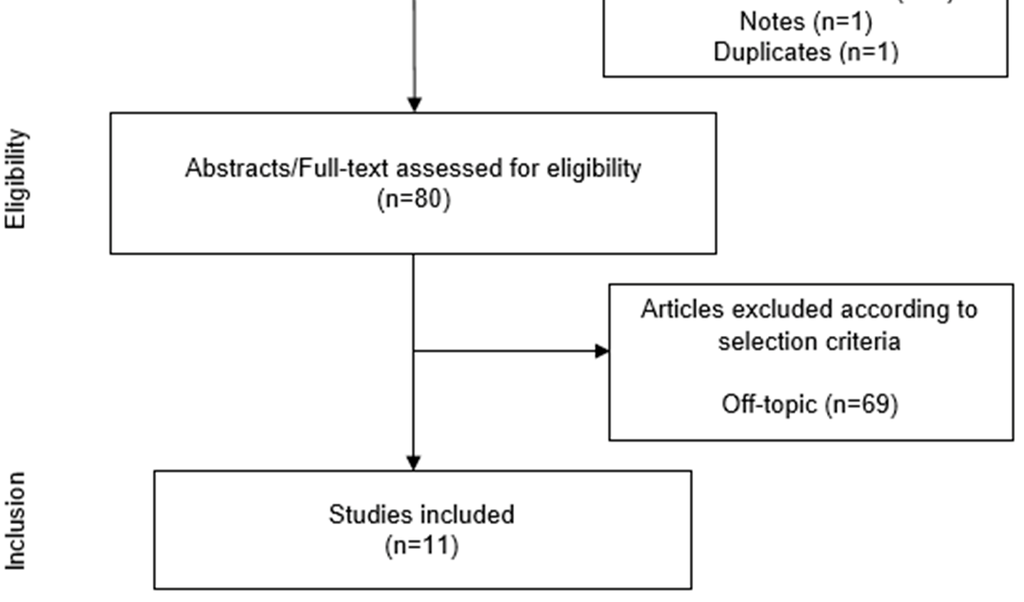

**Figure 1.** Flow diagram for the identiﬁcation of relevant studies.

*Int. J. Mol. Sci.* **2020**, *21*, 4154

5 of 17

**Table 1.** Current evidence of the eﬃcacy of ibrutinib in breast cancer.

**First Author**

**[Ref.]**

**Year**

**Study Type**

**Model**

**Histology**

**Outcome Measures**

**Main Outcomes**

Grabinski

2014

Preclinical:

in vitro

Cell culture

Breast cancer

(HER2<sup>+</sup>)

Cell viability,

phosphorylation of

receptor tyrosine

kinases

Signiﬁcant reduction in the

viability of HER2<sup>+</sup>cell lines

due to ibrutinib.

IC50 values at

nanomolar concentrations.

Synergistic cell viability

reduction of ibrutinib and

PI3K/mTOR

inhibitor dactolisib.

Reduced MAPK and

AKT phosphorylation.

Sagiv-Barﬁ

2015

Preclinical:

in vitro +

in vivo

(animal)

Cell culture,

xenograft

mouse

model

Breast cancer

(TNBC)

Cell viability,

tumor size,

no. of metastases;

Animal survival

Combination of ibrutinib and

anti–PD-L1 inhibits growth

of TNBC.

The combination therapy

generates speciﬁc antitumor

T cells.

Chen

2016

Preclinical:

in vitro +

in vivo

(animal)

Cell culture,

xenograft

mouse

model

Breast cancer

(Her2<sup>+</sup>)

Cell viability,

tumor size,

drug exposure

Inhibition of growth and

suppression of key signaling

pathways in HER2<sup>+</sup>breast

cancer cell lines.

Clinically achievable drug

levels suppress HER2<sup>+</sup>human

breast cancer growth in

xenograft mouse models.

Stiﬀ

2016

Preclinical:

in vitro +

in vivo

(animal)

Cell culture,

xenograft

mouse

model

Breast cancer

(TNBC)

BTK expression,

MDSCs frequency

in vivo (by IHC),

tumor size

Human and murine MDSCs

express BTK.

Ibrutinib modulates MDSCs’

cell function and generation

and diminishes MDSCs in

tumor-bearing mice.

Ibrutinib potentially enhances

immune-based therapies in

solid malignancies.

Wang X

2016

Preclinical:

in vitro +

in vivo

(mice)

Cell culture,

xenograft

mouse

model

Breast cancer

(Her2<sup>+</sup>)

Cell viability,

tumor size

Ibrutinib is more potent in

inhibiting HER2<sup>+</sup>cell than

lapatinib.

Ibrutinib blocks EGFR, HER2,

ErbB3, ErbB4 at its

downstream eﬀectors.

Di

2019

Preclinical:

bioinformatics

Drug

functional

similarity

network

Breast cancer,

ovarian

cancer

Prior score, false

discovery rate

Ibrutinib ranks 3rd in the

prioritized list of candidate

breast cancer drugs and is

considered to have great

potential eﬀects.

Hong

2019

Phase Ib/II

Human

Breast cancer

(TNBC,

HER2<sup>+</sup>),

pancreatic

cancer,

NSCLC

Overall response rate,

progression-free

survival,

overall survival

Recommended phase 2 dose:

560 mg ibrutinib daily,

durvalumab 10 mg/kg i.v. q2w.

ORR: 3% for breast cancer; 2%

for pancreatic cancer; 0%

for NSCLC.

Limited antitumor activity;

acceptable safety proﬁle.

Varikuti

2020

Preclinical:

in vivo

(animal)

Cell culture,

xenograft

mouse

model

Breast cancer

(Luminal B)

Cell viability,

tumor size,

metastasis count,

cell maturation

analysis,

T-cell proliferation

and eﬀector function

Ibrutinib inhibits tumor growth

in vitro.

Treated mice suﬀer lower tumor

burden and less metastases.

MDSCs switch phenotype to

mature dendritic cells in vitro

and less MDSCs and more DCs

in vivo.

Ibrutinib induces antitumor

Th1 and CTL response.

Legend: q2w: every 2 weeks; BTK: Bruton’s tyrosine kinase; i.v.: intravenously; CTL: cytotoxic T lymphocytes;

DC: dendritic cell; IC50: half maximal inhibitory concentration; MDSC: myeloid-derived suppressor cell; NSCLC:

non-small-cell lung cancer; ORR: overall response rate; TNBC: triple-negative breast cancer.

*Int. J. Mol. Sci.* **2020**, *21*, 4154

6 of 17

**Table 2.** Current evidence of the eﬃcacy of ibrutinib in gynecological malignancies.

**First Author**

**[Ref.]**

**Year**

**Study Type**

**Model**

**Histology**

**Outcome Measures**

**Main Outcomes**

Zucha

2015

Pre-clinical:

in vitro

Human tissue

samples, cell culture,

spheroids

Ovarian

cancer

Cell viability,

BTK expression

BTK is a histological biomarker

and a prognostic predictor of

ovarian cancer.

Ovarian CSCs express BTK and

contribute to

cisplatin resistance.

BTK inhibition targets CSCs

and reduces their survival

against cisplatin.

Cisplatin–ibrutinib

combination has synergistic

eﬀects in eliminating ovarian

cancer cells.

Tamura

2018

Preclinical:

in vitro

Cell culture,

patient-derived

tumor organoids

Endometrial

cancer

Tumor size,

inhibitory

concentration

Ibrutinib inhibits the growth of

carboplatin/paclitaxel-resistant

cells at lower concentrations

than carboplatin, paclitaxel,

methotrexate, and vindesine.

Less eﬃcacy in clear-cell

adenocarcinoma cell lines.

Di

2019

Preclinical:

bioinformatics

Drug functional

similarity network

Ovarian

cancer,

breast cancer

Prior score, false

discovery rate

Low rank in ovarian cancer

drug candidates.

Lohse

2019

Preclinical:

in vitro

Drug sensitivity

testing in

patient-derived cell

lines

Ovarian

cancer

Modiﬁed drug

sensitivity scoring

Weak eﬀect on endometrioid

and papillary-serous cell line.

No eﬀect on clear-cell

cancer lines.

Legend: BTK: Bruton’s tyrosine kinase; CSC: cancer stem cells.

**Sti**ﬀ **et al**. investigated the eﬀect of ibrutinib on myeloid-derived suppressor cells (MDSCs) [35].

In tumor-bearing hosts, these cells increased in response to factors released by tumors and stromal

cells, and elevated expression subsequently aﬀected immune response and diminishes the eﬃcacy

of immunotherapy. In their work, they were able to document that human and murine MDSCs

expressed BTK. Furthermore, ibrutinib inhibited the formation of human MDSCs in vitro. In the next

experiment, ibrutinib was fed to mice with xenografted triple-negative mammary tumor cells. This led

to a reduction in immune-suppressing MDSCs in the murine spleen and tumor. Lastly, a murine breast

cancer model was used to assess the eﬃcacy of a combined ibrutinib/anti-PD-L1 treatment, resulting in

a signiﬁcant enhancement of the immunotherapies’ eﬃcacy.

After reporting that an isoform of BTK (BTK-C) protects breast cancer cells from apoptosis in

2013 [36], in 2016, **Wang et al.** showed that inhibition of BTK by ibrutinib could decrease cancer cell

survival and prevent drug resistance [37]. They found that HER2<sup>+</sup>cell lines were more sensitive to

drug treatment than luminal, triple-negative, or even nontumorigenic cell lines in cell growth assays.

The eﬀect of ibrutinib on monolayer and 3D culture was even more potent than that of lapatinib.

As described earlier [33], the phosphorylation of EGFR, HER2, Her3, and ErbB4 was inhibited, resulting

in a blockage of activating downstream pathways. These eﬀects were conﬁrmed in vivo, together with

growth inhibition of the xenografted tumors in mice.

The authors emphasized ibrutinib’s dual eﬀect on two key growth and survival kinases, namely,

BTK and the EGFR family. This might explain its greater impact on HER2<sup>+</sup>cells and provide a strong

rationale for its clinical use, especially since a correlation between the expression of HER2 and BTK

was found in human breast cancer tissue.

As the development of new cancer drugs is slow and costly, **Di et al.** [38] generated a

novel computational approach in order to determine candidate drugs that could possibly be

repurposed to treat cancer.

By using known drug-indication correlations and combining them

with drug-drug and indication-indication similarities, they were subsequently able to hypothesize new

drug-indication associations.

The software used raw data from the National Cancer Institute (NCI)-60 cancer cell line database,

a panel containing extensive data on the gene expression proﬁles and pharmacology for 60 cancer

*Int. J. Mol. Sci.* **2020**, *21*, 4154

7 of 17

cell lines, including breast and ovarian cancer.

These data were used to study the correlation

between mRNA/microRNA expression levels and drug susceptibility. They created a drug-drug

functional similarity network in order to predict drug functional similarities at a biological pathway

level. The system was validated using cross-validation tests on approved drugs, receiver-operating

characteristic curve analysis, and literature searches, conﬁrming its eﬃciency in prioritizing candidate

cancer drugs.

Sixteen FDA approved drugs for the treatment of breast cancer were mapped to the described

network. The algorithm then identiﬁed 14 candidate drugs that were statistically signiﬁcant. In this list

of prioritized scores, ibrutinib ranked 3rd out of more than 3000 substances tested and was “considered

to show great potential therapeutic eﬀects” [38]. Moreover, ranks 1 and 2 (geﬁtinib and afatinib)

represented two EGFR inhibitors, additional proof of the importance of this receptor in breast cancer

treatment. After Sagiv-Barﬁ et al. showed a preclinical eﬀect of ibrutinib and anti-PD-L1 antibodies

in lymphoma, breast cancer, and colon cancer [34], **Hong et al**. initiated an open-label, multicenter,

phase Ib/II study evaluating ibrutinib plus durvalumab in humans [39]. Inclusion criteria included

patients with stage III/IV breast cancer, pancreatic adenocarcinoma, and non-small-cell lung cancer

(NSCLC). After deﬁning a recommended phase 2 dose of 560 mg ibrutinib p.o. daily and durvalumab

been treated with ≥ 2 prior therapies. Ninety-four percent of the patients had stage IV disease at a

median age of 61 years. An overall response rate of 3% was found in patients with breast cancer, with

a median progression-free survival rate of 1.7 months. Pancreatic cancer and NSCLC ranged at an

overall response rate of 2% and 0%, with a median progression-free survival rate of 1.7 and 2.0 months,

respectively. While the safety proﬁles of both drugs were consistent with previously known data

and were considered acceptable, the antitumor activity in this pretreated, late-stage study population

was limited.

**Varikuti et al**. [40] used an orthotopic mouse breast cancer model to investigate ibrutinib’s eﬀect

on tumor progression and metastasis. Mice were injected with tumor cells resembling a luminal b

subtype [41]. After a growth period of one week, mice were randomized to treatment or placebo

groups. Tumor progression, as well as tumor weight, were signiﬁcantly reduced in the treatment

group. BTK expression in tumor tissue was decreased in a dose-dependent manner. Mice receiving

the verum also had fewer lung metastases and splenomegaly when compared to the placebo group.

Immunosuppressive monocytic MDSCs were found to be reduced in the tumors and spleens of

treated mice with an increase in mature dendritic cells (DCs). Furthermore, ibrutinib initiated a

phenotype switch from MDSCs to DCs in vitro. Regarding immune response, the team was able to

show that ibrutinib increased T cell eﬀector functions, encouraged T cell proliferation, and promoted

Th1-dominant cytokines in vivo.

Table 1 shows a summary of the studies described.

2.2.2. Gynecological Malignancies

**Zucha et al.** [42] studied BTK and its inhibition by ibrutinib comprehensively in human ovarian

cancer tissue samples. They demonstrated a high expression of BTK in malignant cells with more

intense staining in metastatic and late-stage disease.

A further experiment demonstrated that cell lines highly resistant to platinum expressed higher

levels of cancer stem cell (CSC) markers than cells with moderate or absent platinum resistance,

indicating a higher fraction of CSCs in these cells.

Next, spheroids from the parental cell lines were generated, and the cisplatin responsiveness

of spheroids and parental cell lines were compared. Spheroids of CSC-rich cell lines showed high

resistance to platinum, indicating a major role of CSCs in cisplatin resistance, while BTK was critical in

regulating ovarian CSCs.

*Int. J. Mol. Sci.* **2020**, *21*, 4154

8 of 17

To prove the hypothesis that BTK mediates platinum resistance via regulation of CSCs,

loss-of-function and gain-of-function studies were performed. In a primarily platinum-responsive cell

line, the overexpression of BTK stimulated the activation of transcription factor STAT3. Consequently,

several downstream eﬀectors, known for their role in stem cell regulation and cell survival, such as SOX2

and Bcl-xL, were upregulated. Following this “stemness” gene regulation, these cells formed spheroids

and increased their CSC count. In contrast, JAK2/STAT3 targets (such as Bcl-xL) were downregulated in

BTK knockdown loss-of-function studies. Treatment with ibrutinib showed a similar eﬀect, decreasing

BTK phosphorylation and Sox2/Bcl-xL expression. This diminished the self-renewal capacities of

highly malignant cells and their proportion of CSCs, which ultimately reduced the population and its

spheroid-forming abilities. Cell lines initially highly resistant to cisplatin became more sensitive after

BTK knockdown. A synergistic eﬀect of ibrutinib and cisplatin was shown in serous and clear cell

lines, indicating the possible use of ibrutinib as a platinum sensitizer in these malignancies.

There also is evidence for an antiproliferative role of ibrutinib in endometrial cancer.

**Tamura et al**. [43] created patient-derived tumor organoids (PDOs) from human tumor tissue (lung,

ovarian, endometrial). The morphology, histology, and gene expression of these organoids were

similar to their source tumor. The reaction to a total of 61 anticancer agents was tested in cell growth

inhibition experiments. Subsequently, the eﬃcacy of each anticancer agent was evaluated. A PDO

called REME9 was derived from carboplatin/paclitaxel-resistant endometrial cancer. As expected,

carboplatin and paclitaxel showed only weak eﬀects on this cell line, an observation that suggested

certain comparability between the PDOs and the source tumor regarding the drug response. Ibrutinib

led to growth inhibition in these cells at concentrations (AUC) notably lower than carboplatin and

paclitaxel, but also lower than MTX and vinca alkaloids—substances that current guidelines recommend

as a possible treatment for metastatic patients. However, ibrutinib had much less eﬀect in clear-cell

adenocarcinoma specimens. A comparison with the eﬀect of anthracyclines was not possible, as this

substance class was not investigated.

The drug-drug functional similarity network created by **Di et al.** [38] has been described in detail

in in Section 2.2.1 above. Even though ibrutinib achieved a high score as a potential agent for breast

cancer treatment, it failed to thrive in the experiments on ovarian cancer and ranged in the last sextile

of the candidate drug list ranking.

As treatment options in platinum-resistant ovarian cancer are scarce, **Lohse et al.** [44] investigated

the treatment response to 30 FDA-approved chemotherapeutics in six such patient-derived cell lines,

using ex vivo drug sensitivity testing. The experiments were performed on two endometrioid, two

clear-cell, and two papillary-serous cell lines, respectively. To interpret and compare the diﬀerent

drugs, the modiﬁed drug sensitivity score was used, a marker incorporating diﬀerent parameters, such

as potency, eﬃcacy, eﬀect range, and therapeutic index, allowing for prioritization of compounds with

one sole numerical metric. In light of this *personalized medicine* approach, diﬀering treatment responses

between cell lines were observed. While docetaxel and cephalomannine diminished the survival of

all cell lines tested, the eﬀect of ibrutinib varied greatly. A weak inhibitory eﬀect was found on one

endometrioid and papillary-serous cell line, respectively, while no eﬀect was seen on clear-cell cancer

lines. Ibrutinib generally provoked less treatment response compared to the tested antimitotics, such

as docetaxel. The response to each drug varied greatly and was partly unpredictable between the

cell lines tested. Afatinib, for example, another kinase inhibitor tested, was the top candidate against

papillary-serous cell line P5X but showed the poorest speciﬁcity against the second papillary-serous

cell line P9A1.

Table 2 shows a summary of the studies investigating ibrutinib in gynecological malignancies.

*2.3. Clinical Trials*

Three trials investigating ibrutinib’s use in gynecological malignancies were identiﬁed. Figure A1

(Appendix A) shows the ﬂow diagram for the identiﬁcation of relevant trials.

*Int. J. Mol. Sci.* **2020**, *21*, 4154

9 of 17

NCT02403271 is a phase Ib/II trial, assessing the safety and eﬃcacy of a combination of ibrutinib

(560 mg daily) and durvalumab in patients with relapsed or refractory solid tumors. As the results have

already been published by Hong et al. [39], please refer to the “Results” section above for further details.

NCT03379428, “Trial of Ibrutinib Plus Trastuzumab in Her2-Ampliﬁed Metastatic Breast Cancer”,

is a phase I/II, open-label, nonrandomized dose-escalation study. Its primary objectives are to deﬁne a

maximum tolerated dose of oral ibrutinib (420, 560 or 840 mg, phase I) and to assess the clinical beneﬁt

rate (phase II) in patients with HER2<sup>+</sup>metastatic breast cancer. At the same time, the patients receive

3-weekly trastuzumab intravenously. With the rationale of continuing a dual HER2 blockade after

the failure of second-line therapy, the inclusion is limited to patients with disease progression after

prior T-DM1. As of May 2020, the trial is active and recruiting, with estimated primary completion in

December 2020.

NCT03525925, “Ibrutinib and Nivolumab in Treating Participants with Metastatic Solid Tumors”,

is a phase I trial investigating the eﬀect of ibrutinib and nivolumab on myeloid-derived suppressor

cells. Patients with metastatic solid neoplasms and any number of prior lines of therapy are eligible

for inclusion. Patients receive oral ibrutinib (420 mg daily) for 15 days and intravenous nivolumab

on days 8 and 21 with subsequent repeated courses of nivolumab every 28 days until disease

progression or unaccepted toxicity. The primary objective is to evaluate the levels of circulating

MDSCs, with a secondary objective being the assessment of the safety of the study combination.

The immunosuppressive potency of MDSCs is measured by their T cell inhibition ability and by

examining antibody-dependent cell toxicity mediated by natural killer cells. The study is active but

not recruiting, with estimated primary completion in September 2020.

In Table 3, we summarized the clinical trials described.

**Table 3.** Clinical trials investigating the use of ibrutinib in gynecological malignancies, including

breast cancer.

**Ref.**

**Title**

**Phase**/ **Status**

**Brief Summary**

**Primary Outcomes**

NCT02403271 [15]

A Multi-Center Study of

Ibrutinib in Combination

with MEDI4736

[Durvalumab] in Subjects

With Relapsed or Refractory

Solid Tumors

Phase Ib/II;

A phase 1b/2, multi-center

study to assess the safety

and eﬃcacy of ibrutinib in

combination with

durvalumab (MEDI4736) in

participants with relapsed or

refractory solid tumors.

Safety and

tolerability,

dosage,

overall response

rate per RECIST 1.1

NCT03379428 [16]

Trial of Ibrutinib Plus

Trastuzumab in

HER2-Ampliﬁed Metastatic

Breast Cancer

Phase I/II;

recruiting <sup>1</sup>

Open-label dose-escalation

study to evaluate the

maximum-tolerated dose

and dose-limiting side

eﬀects of daily oral ibrutinib

in combination with

trastuzumab i.v. q3w,

in patients with

HER2-ampliﬁed metastatic

breast cancer with progress

after prior therapy

with T-DM1.

Maximum-tolerated

dose,

clinical beneﬁt rate

NCT03525925 [17]

Ibrutinib and Nivolumab in

Treating Participants with

Metastatic Solid Tumors

Phase I;

active, not recruiting <sup>1</sup>

A phase I trial investigating

the eﬀect of ibrutinib and

nivolumab on circulating

levels of MDSCs in patients

with metastatic solid tumors

and assessing the safety of

the study combination.

Circulating levels

of myeloid-derived

suppressor cells

1 Recruiting status as of May 1st, 2020.

**3. Discussion**

Ibrutinib has surpassed its initial indication for hematological malignancies and is about to acquire

an increasing *raison d’**ê**tre* in gynecological malignancies and breast cancer. It has become clear that the

mode of action extends beyond B cells, as the compound aﬀects signaling pathways downstream of

multiple other receptors [4,8]. Its promising eﬃcacy on solid tumors can be explained by diﬀerent

means. As diﬀerent tumor types rely on heterogeneous intracellular pathways and greatly vary in

*Int. J. Mol. Sci.* **2020**, *21*, 4154

10 of 17

driver mutations, gene expression, and protein endowment, it is important to note that ibrutinib’s

*modus operandi* in one tumor cannot be transferred to another. The mechanisms described below consist

of complex interactions between the drug, the tumor, and its microenvironment.

First, ibrutinib shows on-target BTK inhibition in certain solid tumors. Ovarian cancer cells

were found to express BTK, correlating with higher clinical disease stage, the risk for metastasis,

and survival [42]. This could be used as both a prognostic predictor and a pharmacological target.

Furthermore, Zucha et al. showed that ibrutinib diminished the self-renewal capacities and the

proportion of CSCs in ovarian cancer due to their BTK dependence. Cisplatin resistance of CSCs

was surmounted, promoting a synergistic eﬀect of both drugs [42]. While the calculations performed

however, did show a weak eﬀect on certain cell lines. Further on-target eﬀects were identiﬁed by

Eifert et al. [36] and Wang et al. [37]. BTK-C, an isoform of BTK, was expressed in 30% of breast cancer

tissue, with an even higher percentage (43%) in HER2<sup>+</sup>tumors. The observed reduction of HER2<sup>+</sup>cell

viability is proposed to be mediated via BTK’s role in the AKT-ERK axis. A synergistic eﬀect between

direct inhibition of BTK (-C) and HER2 (as described below) is likely.

Second, the eﬀects of ibrutinib in- and outside the TEC family kinases, which are linked to the

inhibition of certain additional proteins, do exist. In BTK, ibrutinib covalently binds to a cysteine

residue in the ATP-binding domain. Several other enzymes contain homologous cysteine residues at

analogous positions, as it is conserved among at least nine other tyrosine kinases [2]. An eﬀect has been

described for ERBB family kinases (EGFR, HER2, HER3, HER4), TEC family kinases (TEC, BTK, BMX,

ITK, RLK), and others (JAK3, BLK, FGR, HCK, LCK, Yes/YES1) [8,45]. Even at low concentrations of 1

µmol/L, ibrutinib is able to inhibit 16 kinases by > 95% [46].

Changes in the expression or structure of tyrosine kinase receptors are known to be common in

diﬀerent human cancers and allow for pharmaceutical targeting. Ibrutinib rapidly binds to these targets,

leading to reduced phosphorylation of kinases, such as ErbB1-3 [33]. This inhibition is irreversible,

allowing for its typical once to twice daily dosage despite a short plasma half-life [2].

The inhibitory eﬀect on EGFR has been speciﬁcally explored and is eﬀective in diﬀerent tumor cell

lines, such as EGFR-mutant non-small-cell lung cancer (NSCLC) in mice [7]. Screening of large panels

of cell lines has proved that ibrutinib suppresses the growth of cells suppressed by other EGFR/HER2

inhibitors [2]. Chen et al. did not ﬁnd an eﬀect of ibrutinib on HER2-negative cell lines during several

broad screenings [2], a ﬁnding that strengthens the hypothesis of ERBB family blocking as a main

mode of action.

The eﬀect on the ERBB family, and especially HER2, becomes even more relevant as HER2

overexpression occurs in approximately 20% of breast cancers, resulting in more aggressive subtypes.

In mice xenografted with HER2<sup>+</sup>cells, a signiﬁcant tumor growth inhibition was seen at nanomolar,

clinically achievable concentrations, and is an encouraging result [2,33].

While antibodies targeting HER2 have made their way into everyday clinical practice since long,

experiments in breast cancer cell lines have revealed ibrutinib to be a promising small-molecule

addition to the arsenal. As it is most potent in HER2-overexpressing cell lines, these seem to be among

the most promising candidates for possible future ibrutinib treatment, especially when considering the

synergies described further above. This emphasizes the drug’s multifunctional ability to exert diﬀerent

antineoplastic mechanisms, as outlined earlier. Combining these multiple eﬀects with additional

pharmaceutical drugs, such as trastuzumab, is an auspicious approach and is currently being explored

in a clinical trial [16]. Ibrutinib’s inhibition of bone marrow X-linked kinase (BMX) is another promising

target but remains largely unexplored in gynecological tumors and breast cancer. BMX is overexpressed

in several tumor types and promotes cell proliferation through the PI3K/AKT pathway. Its blockage

could be of interest, especially when combined with PI3K/AKT inhibitors [4]. It has been shown to be

up-regulated in breast and cervical cancer, enhancing cell proliferation, invasiveness, and migration.

*Int. J. Mol. Sci.* **2020**, *21*, 4154

11 of 17

BMX expression correlates with tumor diﬀerentiation and TNM stage [47,48] and is able to increase

apoptotic resistance to chemotherapeutic drugs [49].

Third, immunomodulation relating to MDSC’s and PD-(L)1 seems to play a key role when using

ibrutinib alone or in combination with other therapeutics. MDSCs, which are present in the stroma

of many diﬀerent tumors, have been shown to cause evasion of antitumor immune responses by

immunosuppression and to reduce the eﬃcacy of immune therapy [3,8]. As they express BTK [35],

the corresponding inhibitors may reduce MDSCs in vivo. Additionally, ibrutinib diminishes cytokine

production, PD-L1 expression, and motility of MDSCs and other myeloid cells, which consequently

aﬀects tumor microenvironment regulation and has been linked to decreased tumor vasculature

density [4]. In the murine model of Stiﬀ et al., treatment with ibrutinib resulted in a reduced frequency

of MDSCs in mammary tumors and signiﬁcantly improved the eﬃcacy of anti-PD-L1 therapy in breast

cancer, possibly providing a novel strategy for enhancing immune therapies in solid malignancies [35].

Ibrutinib’s inﬂuence on circulating MDSCs and its synergistic eﬀect with anti-PD1 targeted therapy are

currently under investigation in humans. We highly anticipate the results of NCT03525925 [17] in order

to improve our knowledge about the eﬀects of this promising combination. The observed synergy

of ibrutinib and immune checkpoint inhibition is in line with the work of Sagiv-Barﬁ et al., where

the combination of ibrutinib with anti-PD-L1 agents proved eﬃcient even in tumors (lymphomas)

intrinsically insensitive to ibrutinib, with an approx. 50% cure rate in mice. In their breast cancer model,

a similar eﬀect was found despite BTK negativity and low PD-L1 expression. Hypothesizing that the

synergistic eﬀect of ibrutinib augments the eﬀectiveness of the PD1/PD-L1 blockade by increasing

antitumor T cell response [3], these data suggest a novel role of the compound as a booster of T cell

therapies. An increase of CD4<sup>+</sup>Th1/Th2 cells and tumor-speciﬁc antigen expression by CD8<sup>+</sup>T cells

has been outlined on a molecular basis [4], as elaborated in the next paragraph.

Fourth, antineoplastic eﬀects can be explained by further modulation of adaptive immunity.

One mechanism of tumor immune escape is to induce a Th2-dominant helper T cell response with

antibody production instead of a Th1-dominant response. However, ibrutinib causes a shift towards the

favorable Th1-based immune response and cell-mediated cytotoxicity [45,50,51], leading to increased

maturation of cytotoxic T cells and depletion of immunosuppressive cytokines, such as IL-10 and

TGF-β [3]. This eﬀect is mediated by inhibiting interleukin-2-inducible T cell kinase (ITK), a TEC

kinase that modulates the development and function of T cell immune response [34,45], whereas Th1

and CD8<sup>+</sup>cells can rely on an escape route for maturation [4].

Ibrutinib’s performance varied greatly between animal and human studies in the trials

described [39,40]. These contrasting results are multicausal. As with every experimental model,

it is challenging to transfer the results to humans, adding numerous layers of complexity to a cell

line or animal model. Even highly promising preclinical results had to be abandoned upon failing to

show results in human trials. Nevertheless, the proposed mechanisms of action have been studied

in-depth and sound plausible. The limited data available on human use are insuﬃcient to render a

complete picture of the drug’s capabilities, even more so, as the study population in the phase 1b/2

trial is heavily pretreated and suﬀers end-stage disease, which inevitably leads to short life expectancy

and high drop-out quotas. In future research, clear inclusion criteria, ex vivo sensitivity, and genetic

testing will be crucial in order to select prime candidates. With the optimal patient selection, we are

optimistic that the encouraging preclinical results can be transferred to a broader clinical appliance.

As the paradigm in oncology has shifted from mere inhibition of cell division to a more

holistic approach investigating the tumor and its environment, ibrutinib, with its inhibitory and

immunomodulating eﬀects, takes up an intriguing role. Future research should clearly focus on its use

in HER2<sup>+</sup>tumors as well as its possibilities as an enhancer of chemo- and immune therapy. In the near

future, the results of the ongoing trials NCT03379428 and NCT03525925 could add further evidence in

respect thereof.

*Int. J. Mol. Sci.* **2020**, *21*, 4154

12 of 17

**4. Materials and Methods**

*4.1. Inclusion Criteria*

For this review, studies were considered eligible if they covered (at least in one aspect) the

investigation or use of ibrutinib in gynecological malignancies (including breast cancer) in theoretical

or empirical (human, animal, or in vitro) studies. As per protocol, fundamental research, preclinical,

and clinical studies in English published until April 1, 2020, were considered for this review. We did

not include reviews, conference abstracts, or notes without an abstract. No other restrictions were used.

Clinical trials were considered eligible if they investigated the use of ibrutinib in female genital

tract tumors or breast neoplasms with no further restrictions.

*4.2. Search Strategy*

We performed electronic database searches in EMBASE (DataStar Version, Cary, NC, USA) and

MEDLINE (Ovid version, New York, NY, USA). The search was conducted using the following

Emtree/MeSH terms: “ibrutinib” or “PCI32765” in combination with “female genital tract tumor”

(Emtree) or “genital neoplasms, female” (MeSH), and “breast tumor” (Emtree) or “breast neoplasms”

(MeSH). The Emtree/Mesh terms were expanded in order to include narrower terms (e.g., “ovary

tumor” or “breast cancer”). Boolean operators were used as conjunctions to extend or limit the search,

as described in Tables A1 and A2. All matching publications were screened. The manual exclusion was

performed after screening the titles and/or abstracts to identify eligible publications. The bibliographies

of all articles that fulﬁlled the inclusion criteria were reviewed to identify other articles that fulﬁlled

the inclusion criteria.

Clinical trials were searched in Clinicaltrials.gov (United States Library of Medicine, Bethesda,

MD, USA) using the following terms in the respective search ﬁelds condition or disease: “solid tumor”,

“gynecologic cancer”, “ovarian cancer”, “fallopian tube cancer”, “peritoneal cancer”, “cervical cancer”,

“uterine cancer”, “corpus uteri cancer”, “corpus uteri carcinoma”, “endometrial cancer”, “vaginal

cancer”, “vulvar cancer”, “breast cancer”; other terms (medication): “ibrutinib”.

*4.3. Data Collection Process, Data Items*

Due to inevitable methodological inconsistencies in the studies retrieved and experiments

conducted, standardized data extraction could not be performed.

Findings were extracted

independently in a narrative way to the best of our ability.

**Author Contributions:** Conceptualization, J.M.M. and D.F..; methodology, J.M.M. and L.B.; formal analysis,

J.M.M. and L.B.; investigation, J.M.M.; data curation, J.M.M. and L.B.; writing—original draft preparation, J.M.M.;

writing—review and editing, all authors; visualization, J.M.M.; validation, P.I.; supervision, P.I. and D.F.; project

administration, J.M.M. All authors have read and agreed to the published version of the manuscript.

**Funding:** This research received no external funding.

**Acknowledgments:** Thanks to Carla Trachsel for proofreading the article.

**Conﬂicts of Interest:** The authors declare no conﬂict of interest.

*Int. J. Mol. Sci.* **2020**, *21*, 4154

13 of 17

**Abbreviations**

BMX

Bone marrow X-linked kinase

BTK

Bruton’s tyrosine kinase

cGVHD

Chronic graft versus host disease

CLL

Chronic lymphocytic leukemia

CSC

Cancer stem cell

CTL

Cytotoxic T lymphocytes

DC

Dendritic cell

EGFR

Epidermal growth factor receptor

ER

Estrogene receptor

i.v.

Intravenously

IC50

Half-maximal inhibitory concentration

IFN

Interferon

IL

Interleukin

ITK

interleukin-2-inducible T-cell kinase

MDSC

Myeloid-derived suppressor cell

MeSH

Medical Subject Headings

MZL

Marginal zone lymphoma

NCI

National cancer institute

NSCLC

Non-small-cell lung cancer

ORR

Overall response rate

PARP

poly-ADP-ribose-polymerase

PD-1

Programmed cell death protein 1

PD-L1

Programmed death-ligand 1

PR

Progesterone receptor

q2w

2-weekly, every 2 weeks

RLK

Redundant-resting lymphocyte kinase

SLL

Small lymphocytic lymphoma

TEC

Tec protein tyrosine kinase

TFK

TEC family kinase

TNBC

Triple-negative breast cancer

WM

Waldenstrom’s macroglobulinemia

**Appendix A**

**Table A1.** Search outcomes in Medline. A search performed on 1 April 2020.

**Number**

**Search Terms**

**Search Items Medline**

1

ibrutinib (Mesh)

2026 results

2

(‘genital neoplasms, female’ [Mesh]) OR ‘breast neoplasms’

[Mesh]

498.349 results

3

1 AND 2

4 results

**Table A2.** Search outcomes in Embase. A search performed on 1 April 2020.

**Number**

**Search Terms**

**Search Items Embase**

1

ibrutinib (Emtree)

6186 results

2

‘female genital tract tumor’/exp OR ‘breast tumor/exp’

866.090 results

3

1 AND 2

84 results

*Int. J. Mol. Sci.* **2020**, *21*, 4154

14 of 17

**Search Terms**

**Search Items Embase**

1

ibrutinib (Emtree)

6186 results

2

3

1 AND 2

84 results

1.

selective pressure in T lymphocytes. *Blood* **2013**, *122*, 2539–2549, doi:10.1182/blood-2013-06-507947.

2.

doi:10.1158/1535-7163.MCT-15-0923.

3.

Campbell, R.; Chong, G.; Hawkes, E. Novel Indications for Bruton’s Tyrosine Kinase Inhibitors, beyond

Hematological Malignancies. *J. Clin. Med.* **2018**, *7*, 62, doi:10.3390/jcm7040062.

4.

5.

Pharmacyclics Inc. Imbruvica® (ibrutinib) [package insert]. U.S. Food and Drug Administration website.

Available

online:

www.accessdata.fda.gov/drugsatfda_docs/label/2019/205552s029,210563s004lbl.pdf

(revised July 2019, accessed on January 1, 2020)*.*

6.

suppressing glioma tumorigenesis and stem cell phenotypes. *Oncotarget* **2016**, *7*, 69961–69975,

doi:10.18632/oncotarget.11572.

7.

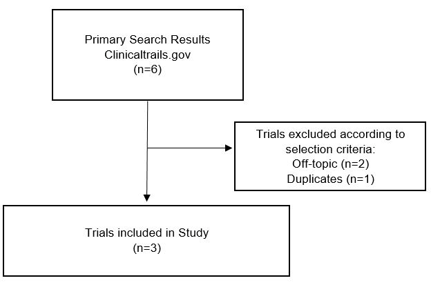

**Figure A1.** Search results of clinical trials.

**References**

1.

Dubovsky, J.A.; Beckwith, K.A.; Natarajan, G.; Woyach, J.A.; Jaglowski, S.; Zhong, Y.; Hessler, J.D.; Liu, T.-M.;

Chang, B.Y.; Larkin, K.M.; et al. Ibrutinib is an irreversible molecular inhibitor of ITK driving a Th1-selective

pressure in T lymphocytes. *Blood* **2013**, *122*, 2539–2549. [CrossRef] [PubMed]

2.

Chen, J.; Kinoshita, T.; Sukbuntherng, J.; Chang, B.Y.; Elias, L. Ibrutinib Inhibits ERBB Receptor Tyrosine

Kinases and HER2-Ampliﬁed Breast Cancer Cell Growth. *Mol. Cancer Ther.* **2016**, *15*, 2835–2844. [CrossRef]

[PubMed]

3.

Campbell, R.; Chong, G.; Hawkes, E. Novel Indications for Bruton’s Tyrosine Kinase Inhibitors, beyond

Hematological Malignancies. *J. Clin. Med.* **2018**, *7*, 62. [CrossRef] [PubMed]

4.

Molina-Cerrillo, J.; Alonso-Gordoa, T.; Gajate, P.; Grande, E. Bruton’s tyrosine kinase (BTK) as a promising

target in solid tumors. *Cancer Treat. Rev.* **2017**, *58*, 41–50. [CrossRef] [PubMed]

5.

Pharmacyclics Inc.

Imbruvica®(ibrutinib) [package insert].

U.S. Food and Drug Administration

Website. Available online: www.accessdata.fda.gov/drugsatfda_docs/label/2019/205552s029,210563s004lbl.pdf

(accessed on 1 January 2020).

6.

Wei, L.; Su, Y.-K.; Lin, C.-M.; Chao, T.-Y.; Huang, S.-P.; Huynh, T.-T.; Jan, H.-J.; Whang-Peng, J.; Chiou, J.-F.;

Wu, A.T.; et al. Preclinical investigation of ibrutinib, a Bruton’s kinase tyrosine (Btk) inhibitor, in suppressing

glioma tumorigenesis and stem cell phenotypes. *Oncotarget* **2016**, *7*, 69961–69975. [CrossRef] [PubMed]

7.

Gao, W.; Wang, M.; Wang, L.; Lu, H.; Wu, S.; Dai, B.; Ou, Z.; Zhang, L.; Heymach, J.V.; Gold, K.A.; et al.

Selective Antitumor Activity of Ibrutinib in EGFR-Mutant Non–Small Cell Lung Cancer Cells. *J. Natl.*

*Cancer Inst.* **2014**, *106*. [CrossRef] [PubMed]

8.

Massó-Vallés, D.; Jauset, T.; Soucek, L. Ibrutinib repurposing: From B-cell malignancies to solid tumors.

*Oncoscience* **2016**, *3*, 147–148. [CrossRef] [PubMed]

9.

Bond, D.A.; Woyach, J.A. Targeting BTK in CLL: Beyond Ibrutinib. *Curr. Hematol. Malign. Rep.* **2019**, *14*,

197–205. [CrossRef] [PubMed]

10.

Atkinson, B.T.; Ellmeier, W.; Watson, S.P. Tec regulates platelet activation by GPVI in the absence of Btk.

*Blood* **2003**, *102*, 3592–3599. [CrossRef] [PubMed]

11.

Quek, L.; Bolen, J.; Watson, S.P. A role for Bruton’s tyrosine kinase (Btk) in platelet activation by collagen.

*Curr. Biol.* **1998**, *8*, 1137–1140. [CrossRef]

12.

Younes, A.; Thieblemont, C.; Morschhauser, F.; Flinn, I.W.; Friedberg, J.W.; Amorim, S.; Hivert, B.; Westin, J.;

Vermeulen, J.; Bandyopadhyay, N.; et al. Combination of ibrutinib with rituximab, cyclophosphamide,

doxorubicin, vincristine, and prednisone (R-CHOP) for treatment-naive patients with CD20-positive B-cell

non-Hodgkin lymphoma: A non-randomised, phase 1b study. *Lancet Oncol.* **2014**, *15*, 1019–1026. [CrossRef]

13.

Jaglowski, S.M.; Jones, J.A.; Nagar, V.; Flynn, J.M.; Andritsos, L.A.; Maddocks, K.J.; Woyach, J.A.; Blum, K.A.;

Grever, M.R.; Smucker, K.; et al. Safety and activity of BTK inhibitor ibrutinib combined with ofatumumab

in chronic lymphocytic leukemia: A phase 1b/2 study. *Blood* **2015**, *126*, 842–850. [CrossRef] [PubMed]

*Int. J. Mol. Sci.* **2020**, *21*, 4154

15 of 17

14.

Chanan-Khan, A.; Cramer, P.; Demirkan, F.; Fraser, G.; Silva, R.S.; Grosicki, S.; Pristupa, A.; Janssens, A.;

Mayer, J.; Bartlett, N.L.; et al. Ibrutinib combined with bendamustine and rituximab compared with placebo,

bendamustine, and rituximab for previously treated chronic lymphocytic leukaemia or small lymphocytic

lymphoma (HELIOS): A randomised, double-blind, phase 3 study. *Lancet Oncol.* **2016**, *17*, 200–211. [CrossRef]

15.

A Multi-Center Study of Ibrutinib in Combination with MEDI4736 in Subjects With Relapsed or Refractory

Solid Tumors. Available online: https://ClinicalTrials.gov/show/NCT02403271 (accessed on 30 April 2020).

16.

Trial of Ibrutinib Plus Trastuzumab in HER2-amplified Metastatic Breast Cancer. Available online: https:

//ClinicalTrials.gov/show/NCT03379428 (accessed on 30 April 2020).

17.

Ibrutinib and Nivolumab in Treating Participants with Metastatic Solid Tumors. Available online: https:

//ClinicalTrials.gov/show/NCT03525925 (accessed on 30 April 2020).

18.

Wu, J.; Liu, C.; Tsui, S.T.; Liu, D. Second-generation inhibitors of Bruton tyrosine kinase. *J. Hematol. Oncol.*

**2016**, *9*, 80. [CrossRef] [PubMed]

19.

AstraZeneca. Calquence®(acalabrutinib) [package insert]. U.S. Food and Drug Administration website.

Available online: www.accessdata.fda.gov/drugsatfda_docs/label/2019/210259s006s007lbl.pdf (accessed on

27 May 2020).

20.

Wu, J.; Zhang, M.; Liu, D. Acalabrutinib (ACP-196):

A selective second-generation BTK inhibitor.

*J. Hematol. Oncol.* **2016**, *9*, 21. [CrossRef] [PubMed]

21.

Barf, T.; Covey, T.; Izumi, R.; Van De Kar, B.; Gulrajani, M.; Van Lith, B.; Van Hoek, M.; De Zwart, E.;

Mittag, D.; Demont, D.; et al. Acalabrutinib (ACP-196): A Covalent Bruton Tyrosine Kinase Inhibitor with a

Diﬀerentiated Selectivity and In Vivo Potency Proﬁle. *J. Pharmacol. Exp. Ther.* **2017**, *363*, 240–252. [CrossRef]

[PubMed]

22.

BeiGene. Brukinsa®(zanubrutinib) [package insert]. U.S. Food and Drug Administration website. Available

online: www.accessdata.fda.gov/drugsatfda_docs/label/2019/213217s000lbl.pdf (accessed on 27 May 2020).

23.

Liclican, A.; Seraﬁni, L.; Xing, W.; Czerwieniec, G.; Steiner, B.; Wang, T.; Brendza, K.M.; Lutz, J.D.; Keegan, K.S.;

Ray, A.S.; et al. Biochemical characterization of tirabrutinib and other irreversible inhibitors of Bruton’s

tyrosine kinase reveals diﬀerences in on—and oﬀ—arget inhibition. *Biochim. Biophys. Acta BBA Gen. Subj.*

**2020**, *1864*, 129531. [CrossRef] [PubMed]

24.

Caldwell, R.D.; Qiu, H.; Askew, B.C.; Bender, A.T.; Brugger, N.; Camps, M.; Dhanabal, M.; Dutt, V.;

Eichhorn, T.; Gardberg, A.S.; et al. Discovery of Evobrutinib: An Oral, Potent, and Highly Selective, Covalent

Bruton’s Tyrosine Kinase (BTK) Inhibitor for the Treatment of Immunological Diseases. *J. Med. Chem.* **2019**,

*62*, 7643–7655. [CrossRef] [PubMed]

25.

Study of Evobrutinib in Participants with Relapsing Multiple Sclerosis (RMS). Available online: https:

//ClinicalTrials.gov/show/NCT04032158 (accessed on 27 May 2020).

26.

Armstrong, D.K.; Alvarez, R.D.; Bakkum-Gamez, J.N.; Barroilhet, L.; Behbakht, K.; Berchuck, A.; Berek, J.S.;

Chen, L.-M.; Cristea, M.; DeRosa, M.; et al. NCCN Guidelines Insights: Ovarian Cancer, Version 1.2019.

*J. Natl. Compr. Cancer Netw.* **2019**, *17*, 896–909. [CrossRef] [PubMed]

27.

Bottoni, P.; Scatena, R. The Role of CA 125 as Tumor Marker: Biochemical and Clinical Aspects. *Adv. Exp.*

*Med. Biol.* **2015**, *867*, 229–244. [CrossRef] [PubMed]

28.

Ledermann, J.A.; Pujade-Lauraine, E. Olaparib as maintenance treatment for patients with platinum-sensitive

relapsed ovarian cancer. *Ther. Adv. Med. Oncol.* **2019**, *11*, 1758835919849753. [CrossRef] [PubMed]

29.

Colombo, N.; Sessa, C.; Du Bois, A.; Ledermann, J.; McCluggage, W.G.; McNeish, I.; Morice, P.; Pignata, S.;

Ray-Coquard, I.; Vergote, I.; et al. ESMO–ESGO consensus conference recommendations on ovarian cancer:

Pathology and molecular biology, early and advanced stages, borderline tumours and recurrent disease.

*Ann. Oncol.* **2019**, *30*, 672–705. [CrossRef] [PubMed]

30.

National Comprehensive Cancer Network. Ovarian Cancer (Version 1.2020). Available online: https://www.

nccn.org/professionals/physician_gls/pdf/ovarian.pdf (accessed on 29 March 2020).

31.

Siegel, R.L.; Miller, K.D.; Jemal, A. Cancer statistics, 2019. *CA Cancer J. Clin.* **2019**, *69*, 7–34. [CrossRef]

[PubMed]

32.

Waks, A.G.; Winer, E.P. Breast Cancer Treatment: A Review. *JAMA* **2019**, *321*, 288–300. [CrossRef] [PubMed]

33.

Grabinski, N.; Ewald, F. Ibrutinib (ImbruvicaTM) potently inhibits ErbB receptor phosphorylation and cell

viability of ErbB2-positive breast cancer cells. *Investig. New Drugs* **2014**, *32*, 1096–1104. [CrossRef] [PubMed]

*Int. J. Mol. Sci.* **2020**, *21*, 4154

16 of 17

34.

Sagiv-Barﬁ, I.; Kohrt, H.E.K.; Czerwinski, D.K.; Ng, P.P.; Chang, B.Y.; Levy, R. Therapeutic antitumor

immunity by checkpoint blockade is enhanced by ibrutinib, an inhibitor of both BTK and ITK. *Proc. Natl.*

*Acad. Sci. USA* **2015**, *112*, E966–E972. [CrossRef] [PubMed]

35.

Stiﬀ, A.; Trikha, P.; Wesolowski, R.; Kendra, K.; Hsu, V.; Uppati, S.; McMichael, E.L.; Duggan, M.; Campbell, A.;

Keller, K.; et al. Myeloid-Derived Suppressor Cells Express Bruton’s Tyrosine Kinase and Can Be Depleted in

Tumor-Bearing Hosts by Ibrutinib Treatment. *Cancer Res.* **2016**, *76*, 2125–2136. [CrossRef] [PubMed]

36.

Eifert, C.; Wang, X.; Kokabee, L.; Kourtidis, A.; Jain, R.; Gerdes, M.J.; Conklin, D.S. A novel isoform of the

B cell tyrosine kinase BTK protects breast cancer cells from apoptosis. *Genes Chromosom. Cancer* **2013**, *52*,

961–975. [CrossRef] [PubMed]

37.

Wang, X.; Wong, J.; Sevinsky, C.J.; Kokabee, L.; Khan, F.; Sun, Y.; Conklin, D.S. Bruton’s Tyrosine Kinase

Inhibitors Prevent Therapeutic Escape in Breast Cancer Cells. *Mol. Cancer Ther.* **2016**, *15*, 2198–2208.

[CrossRef] [PubMed]

38.

Di, J.; Zheng, B.; Kong, Q.; Jiang, Y.; Liu, S.; Yang, Y.; Han, X.; Sheng, Y.; Zhang, Y.; Cheng, L.; et al.

Prioritization of candidate cancer drugs based on a drug functional similarity network constructed by

integrating pathway activities and drug activities. *Mol. Oncol.* **2019**, *13*, 2259–2277. [CrossRef] [PubMed]

39.

Hong, D.S.; Rasco, D.; Veeder, M.; Luke, J.J.; Chandler, J.; Balmanoukian, A.; George, T.J.; Munster, P.;

Berlin, J.D.; Gutierrez, M.; et al. A Phase 1b/2 Study of the Bruton Tyrosine Kinase Inhibitor Ibrutinib and

the PD-L1 Inhibitor Durvalumab in Patients with Pretreated Solid Tumors. *Oncology* **2019**, *97*, 102–111.

[CrossRef] [PubMed]

40.

Varikuti, S.; Singh, B.; Volpedo, G.; Ahirwar, D.K.; Jha, B.K.; Saljoughian, N.; Viana, A.G.; Verma, C.;

Hamza, O.; Halsey, G.; et al. Ibrutinib treatment inhibits breast cancer progression and metastasis by

inducing conversion of myeloid-derived suppressor cells to dendritic cells. *Br. J. Cancer* **2020**, *122*, 1005–1013.

[CrossRef] [PubMed]

41.

Le Naour, A.; Koﬃ, Y.; Diab, M.; Le Guennec, D.; Rougé, S.; Aldekwer, S.; Goncalves-Mendes, N.; Talvas, J.;

Farges, M.; Caldeﬁe-Chezet, F.; et al. The EO771 mammary cancer cell line displays a luminal B phenotype

and it is sensitive to anti-estrogen treatments. *Biorxiv* **2019**. [CrossRef]

42.

Zucha, M.A.; Wu, A.T.; Lee, W.H.; Wang, L.S.; Lin, W.W.; Yuan, C.C.; Yeh, C.T. Bruton’s tyrosine kinase (Btk)

inhibitor ibrutinib suppresses stem-like traits in ovarian cancer. *Oncotarget* **2015**, *6*, 13255–13268. [CrossRef]

[PubMed]

43.

Tamura, H.; Higa, A.; Hoshi, H.; Hiyama, G.; Takahashi, N.; Ryufuku, M.; Morisawa, G.; Yanagisawa, Y.;

Ito, E.; Imai, J.I.; et al. Evaluation of anticancer agents using patient-derived tumor organoids characteristically

similar to source tissues. *Oncol. Rep.* **2018**, *40*, 635–646. [CrossRef] [PubMed]

44.

Lohse, I.; Azzam, D.J.; Al-Ali, H.; Volmar, C.H.; Brothers, S.P.; Ince, T.A.; Wahlestedt, C. Ovarian Cancer

Treatment Stratiﬁcation Using Ex Vivo Drug Sensitivity Testing. *Anticancer Res.* **2019**, *39*, 4023–4030.

[CrossRef] [PubMed]

45.

Berglof, A.; Hamasy, A.; Meinke, S.; Palma, M.; Krsti´c, A.; Månsson, R.; Kimby, E.; Österborg, A.; Smith, C.I.E.

Targets for Ibrutinib Beyond B Cell Malignancies. *Scand. J. Immunol.* **2015**, *82*, 208–217. [CrossRef] [PubMed]

46.

Uitdehaag, J.C.M.; Kooijman, J.J.; De Roos, J.A.M.; Prinsen, M.B.W.; Dylus, J.; Willemsen-Seegers, N.;

Kawase, Y.; Sawa, M.; De Man, J.; Van Gerwen, S.J.C.; et al. Combined Cellular and Biochemical Proﬁling to

Identify Predictive Drug Response Biomarkers for Kinase Inhibitors Approved for Clinical Use between

2013 and 2017. *Mol. Cancer Ther.* **2019**, *18*, 470–481. [CrossRef] [PubMed]

47.

Li, K.; Pan, W.-T.; Ma, Y.-B.; Xu, X.-L.; Gao, Y.; He, Y.-Q.; Wei, L.; Zhang, J.-W. BMX activates Wnt/β-catenin

signaling pathway to promote cell proliferation and migration in breast cancer. *Breast Cancer* **2019**, *27*,

363–371. [CrossRef] [PubMed]

48.

Li, Y.; Cui, N.; Zheng, P.-S.; Yang, W.-T. BMX/Etk promotes cell proliferation and tumorigenicity of cervical

cancer cells through PI3K/AKT/mTOR and STAT3 pathways. *Oncotarget* **2017**, *8*, 49238–49252. [CrossRef]

[PubMed]

49.

Fox, J.L.; Storey, A. BMX Negatively Regulates BAK Function, Thereby Increasing Apoptotic Resistance to

Chemotherapeutic Drugs. *Cancer Res.* **2015**, *75*, 1345–1355. [CrossRef] [PubMed]

*Int. J. Mol. Sci.* **2020**, *21*, 4154

17 of 17

50.

Horna, P.; Sotomayor, E.M. Cellular and molecular mechanisms of tumor-induced T-cell tolerance. *Curr. Cancer*

*Drug Targets* **2007**, *7*, 41–53. [CrossRef] [PubMed]

51.

Loose, D.; Van De Wiele, C. The Immune System and Cancer. *Cancer Biother. Radiopharm.* **2009**, *24*, 369–376.

[CrossRef] [PubMed]

[figure not shown]

© 2020 by the authors. Licensee MDPI, Basel, Switzerland. This article is an open access

article distributed under the terms and conditions of the Creative Commons Attribution

(CC BY) license (http://creativecommons.org/licenses/by/4.0/).